# Chapter 4 - Exploring Data with Graphs

Sarah Hedvig Dahl Nielsen

24/9/2019

### Packages used

```r
pacman::p_load(ggplot2)
```

### Data

The data is from the Companion website https://studysites.uk.sagepub.com/dsur/study/articles.htm

```r
facebookData <- read.delim("FacebookNarcissism.dat", header = TRUE)
examData <- read.delim("Exam Anxiety.dat", header = TRUE)
festivalData <- read.delim("DownloadFestival.dat", header = TRUE)
```

### Plots

#### Exercise 1

In the first exercise we use the facebookData. It contains the following four variables

- id: a number indicating from which participant the profile photo came
- NPQC_R_Total: the total score on the narcissism questionnaire
- Rating_Type: whether the rating was for coolness, glamour, fashion or attractiveness (stored as strings of text)
- Rating: the rating given (on a scale from 1 to 5)

##### Exercise 1.1

The aim is to plot the relationship between narcissism (NPQC_R_Total) against the general profile ratings (Rating)

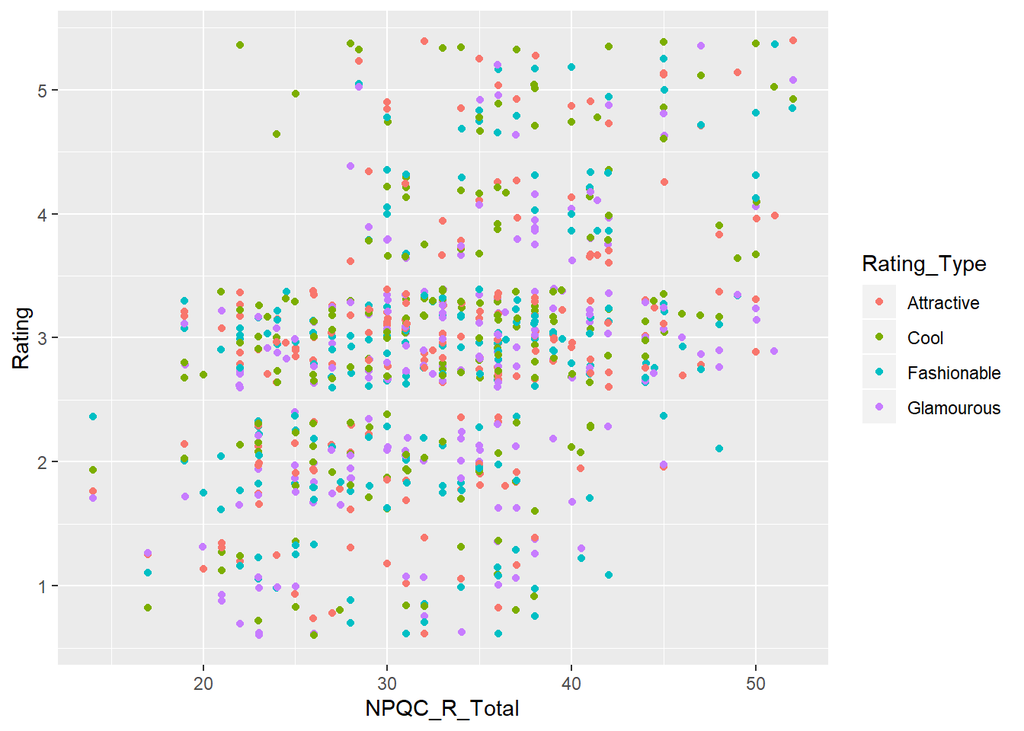

```r
ggplot(facebookData, aes(NPQC_R_Total, Rating)) + geom_point(aes(color = Rating_Type), position = "jitter")
```

##### Exercise 1.2

Plot a graph that shows the pattern in the data using only a line.

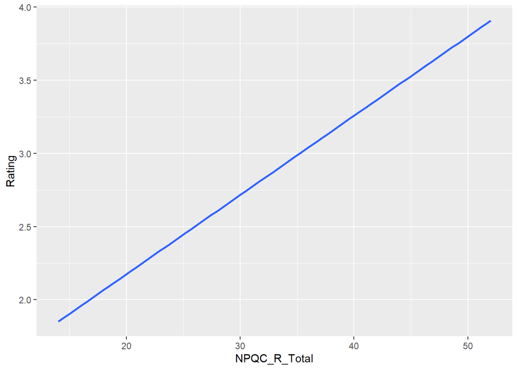

```r
ggplot(facebookData, aes(NPQC_R_Total, Rating)) + geom_smooth(method = lm, se = F)
```

##### Exercise 1.3

- Plot different coloured lines for the different types of rating (cool, fashionable, attractive, glamorous)
- Add a layer displaying the raw data as points

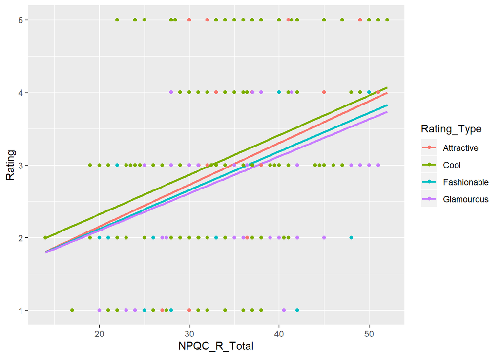

```r
ggplot(facebookData, aes(NPQC_R_Total, Rating, color = Rating_Type)) + geom_smooth(method = lm, se = F) + geom_point()
```

#### Exercise 2

In the second exercise we use the exam anxiety data. It contains the following 5 variables

- Code: a number indicating from which participant the scores came
- Revise: the total hours spent revising
- Exam: mark on the exam as a percentage
- Anxiety: the score on the EAQ
- Gender: Whether the participant was male or female

##### Exercise 2.1

The aim is to plot anxiety levels against exam performance and do a linear regression.

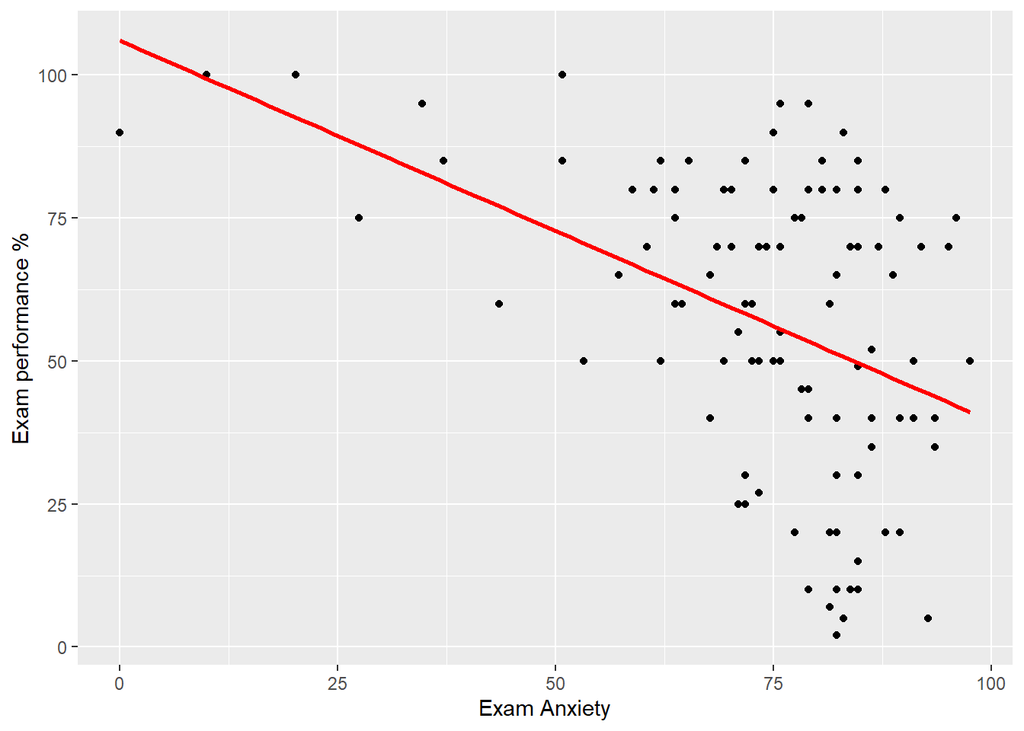

```r
ggplot(examData, aes(Anxiety, Exam)) + geom_point() + geom_smooth(method = "lm", color = "Red", se = F) + labs(x = "Exam Anxiety", y = "Exam performance %")
```

##### Exercise 2.2

In this exercise we will build on the scatterplot from ‘Exercise 2’ to see whether gender affects the reaction to exam anxiety.

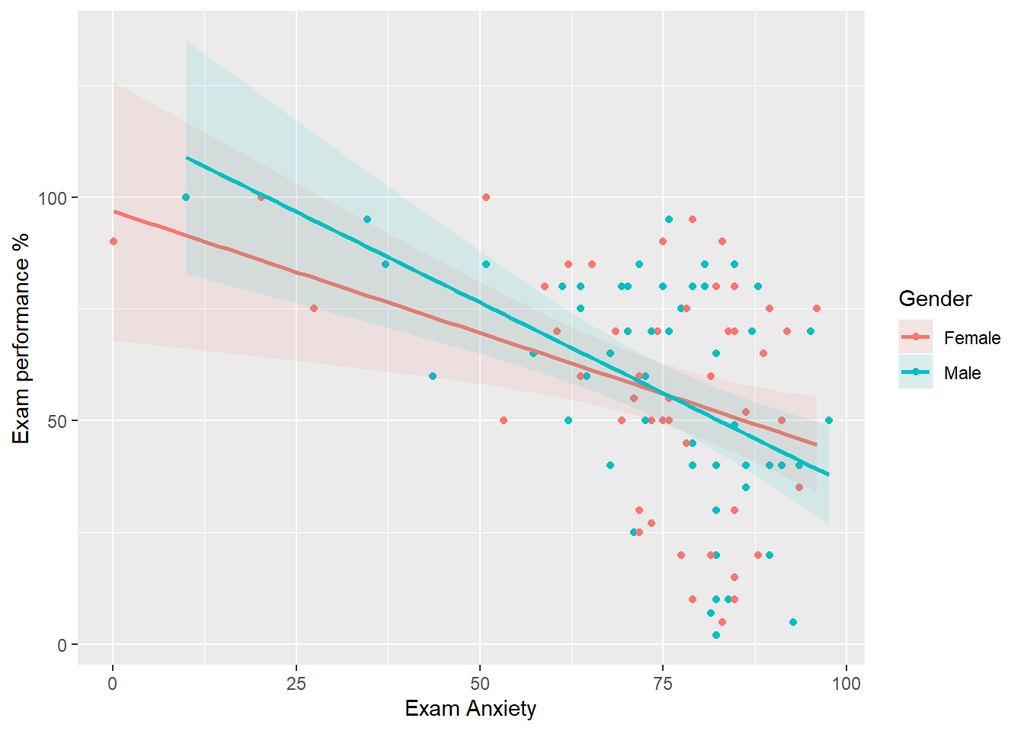

```r
ggplot(examData, aes(Anxiety, Exam, colour = Gender)) + geom_point() + geom_smooth(method = "lm", aes(fill = Gender), alpha = 0.1) + labs(x = "Exam Anxiety", y = "Exam performance %")
```

#### Exercise 3

In exercise 3 we use the festival data

##### Exercise 3.1

Making a histogram

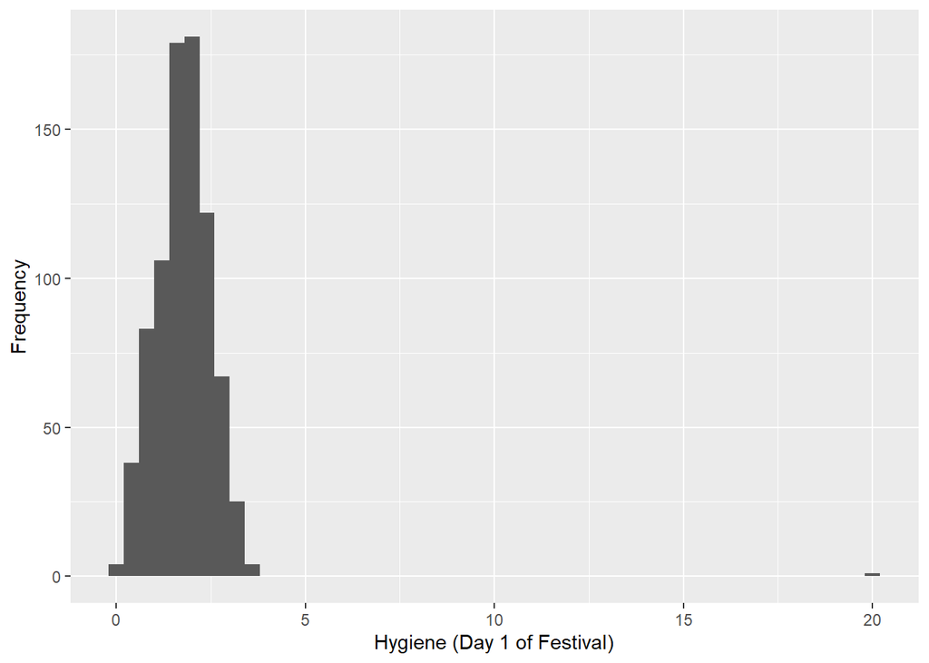

```r
ggplot(festivalData,aes(day1)) + geom_histogram(binwidth = 0.4) + labs(x = "Hygiene (Day 1 of Festival)", y = "Frequency")
```